# Eddie Ice Phenology R Notebook

# 1970 Break point analysis

There are a few ways to do this analysis… ## 1. The really manual method This method creates separate dataframes for pre and post and then does the above approach

## Extract only sunapee pre 1970 data

```r
sunapee_pre1970.df <- sunapee.df %>% # use the sunapee data set
  filter( # filter out some of the data to retain
    pre_post_1970 == "pre_1970") # this filters out only pre_1970 data in the pre_post_1970 column
# all of this is saved in the sunapee_pre1970.df dataframe
```

## Extract only sunapee post 1970 data

```r
sunapee_post1970.df <- sunapee.df %>% # use the sunapee data set
  filter( # filter out some of the data to retain
    pre_post_1970 == "post_1970") # this filters out only pre_1970 data in the pre_post_1970 column
# all of this is saved in the sunapee_pre1970.df dataframe
```

## Sunapee pre 1970 model

```r
sunapee_pre1970.model <- lm(ice_off_julian ~ start_year, data = sunapee_pre1970.df)
```

## Pre 1970 model summary

To see the data from the model you run this below

```r
summary(sunapee_pre1970.model)
```

```
Call:
lm(formula = ice_off_julian ~ start_year, data = sunapee_pre1970.df)

Residuals:
    Min      1Q  Median      3Q     Max
-26.992  -5.216   1.440   6.430  16.605

Coefficients:
             Estimate Std. Error t value Pr(>|t|)
(Intercept) 314.04384   61.73621   5.087 1.71e-06 ***
start_year   -0.10310    0.03216  -3.206  0.00181 **
---
Signif. codes:  0 ‘***’ 0.001 ‘**’ 0.01 ‘*’ 0.05 ‘.’ 0.1 ‘ ’ 1

Residual standard error: 9.563 on 100 degrees of freedom
Multiple R-squared:  0.0932,    Adjusted R-squared:  0.08413
F-statistic: 10.28 on 1 and 100 DF,  p-value: 0.001808
```

*Prey 1970 Model output* Call: lm(formula = ice_off_julian ~ start_year, data = sunapee_pre1970.df)

Residuals:  
Min 1Q Median 3Q Max  
-26.992 -5.216 1.440 6.430 16.605

Residual standard error: 9.563 on 100 degrees of freedom  
Multiple R-squared: 0.0932, Adjusted R-squared: 0.08413  
F-statistic: 10.28 on 1 and 100 DF, p-value: 0.001808

```r
sunapee_post1970.model <- lm(ice_off_julian ~ start_year, data = sunapee_post1970.df)
```

## Post 1970 model summary

To see the data from the model you run this below

```r
summary(sunapee_post1970.model)
```

```
Call:
lm(formula = ice_off_julian ~ start_year, data = sunapee_post1970.df)

Residuals:
     Min       1Q   Median       3Q      Max
-24.1395  -4.9908   0.5587   6.0430  15.9264

Coefficients:
             Estimate Std. Error t value Pr(>|t|)
(Intercept) 641.81466  191.59047   3.350  0.00172 **
start_year   -0.26674    0.09615  -2.774  0.00823 **
---
Signif. codes:  0 ‘***’ 0.001 ‘**’ 0.01 ‘*’ 0.05 ‘.’ 0.1 ‘ ’ 1

Residual standard error: 8.099 on 42 degrees of freedom
Multiple R-squared:  0.1549,    Adjusted R-squared:  0.1347
F-statistic: 7.695 on 1 and 42 DF,  p-value: 0.008225
```

*Model Output* Call:  
lm(formula = ice_off_julian ~ start_year, data = sunapee_post1970.df)

Residuals:  
Min 1Q Median 3Q Max  
-24.1395 -4.9908 0.5587 6.0430 15.9264

Residual standard error: 8.099 on 42 degrees of freedom  
Multiple R-squared: 0.1549, Adjusted R-squared: 0.1347  
F-statistic: 7.695 on 1 and 42 DF, p-value: 0.008225

## 2 The better approach

The second way to do this without splititng the dataframe

```r
sunapee_pre_post.model <- sunapee.df %>%
  group_by(pre_post_1970) %>% # this grpups the data into the groups listed in this variable
  do(pre_post.model = lm(ice_off_julian ~ start_year, # this does the model in two steps
                         data = .)) # tells it to use the data fred into the model above
```

## summary of tidy model

This saves the coefficients out to a new dataframe and does the summary of the model what model and the column to use of teh groups.

```r
sunapee_pre_post.coef <- tidy(sunapee_pre_post.model, pre_post.model)
sunapee_pre_post.coef # prints out the dataframe
```

| pre_post_1970 | term | estimate | std.error | statistic | p.value |
| --- | --- | --- | --- | --- | --- |
| post_1970 | (Intercept) | 641.8146582 | 191.59047335 | 3.349930 | 1.716545e-03 |
| post_1970 | start_year | -0.2667371 | 0.09615387 | -2.774066 | 8.225111e-03 |
| pre_1970 | (Intercept) | 314.0438392 | 61.73620516 | 5.086867 | 1.706244e-06 |
| pre_1970 | start_year | -0.1030981 | 0.03215887 | -3.205899 | 1.808075e-03 |

## Plotting pre and post 1970

You can see the graph with both lines

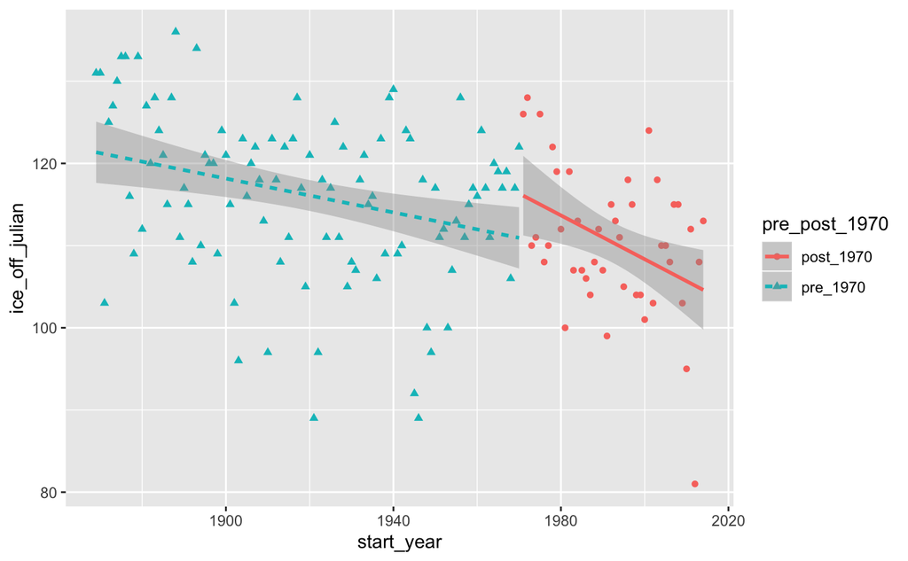

```r
sunapee.df %>%
  ggplot(aes(start_year, ice_off_julian,
             color=pre_post_1970, # this maps a color to the points based on the column
             shape=pre_post_1970, # this maps a symbol shape to the column
             linetype=pre_post_1970)) + # this changes the line time based on the column
  geom_point() + # add in points
  geom_smooth(method="lm") # add in a smoothed line
```